# Introduction

[figure not shown]

This is a Portfolio Project from 100 Days of Code: The Complete Python Pro Bootcamp.

This dataset was scraped from [nextspaceflight.com](https://nextspaceflight.com/launches/past/?page=1) and includes all the space missions since the beginning of Space Race between the USA and the Soviet Union in 1957.

### Upgrade Plotly

and install dataprep

```python
%pip install --upgrade plotly
```

```python
%pip install dataprep
```

### Import Statements

```python
import numpy as np
import pandas as pd
import plotly.express as px
import matplotlib.pyplot as plt
import seaborn as sns
import matplotlib.patches as mpatches

from datetime import datetime, timedelta
from dataprep.clean import clean_country
```

### Notebook Presentation

```python
pd.options.display.float_format = '{:,.2f}'.format
```

### Load the Data

```python
df_data = pd.read_csv('mission_launches.csv')
```

# Preliminary Data Exploration

- What is the shape of `df_data`
- How many rows and columns does it have?
- What are the column names?
- Are there any NaN values or duplicates?

```python
df_data.shape
```

```
(4324, 9)
```

```python
df_data.columns
```

```
Index(['Unnamed: 0.1', 'Unnamed: 0', 'Organisation', 'Location', 'Date',
       'Detail', 'Rocket_Status', 'Price', 'Mission_Status'],
      dtype='object')
```

```python
df_data.isna().values.any()
```

```
True
```

```python
df_data.isna().values.sum()
```

```
3360
```

```python
df_data.duplicated().values.sum()
```

```
0
```

- The dataset has 9 columns ('Unnamed: 0.1', 'Unnamed: 0', 'Organisation', 'Location', 'Date', 'Detail', 'Rocket_Status', 'Price', 'Mission_Status') and 4324 rows.
- It contains 3360 NaN values and 0 duplicates.

## Data Cleaning - Check for Missing Values and Duplicates

Looking at our dataset and the datatypes we are working with, we can see there are 2 columns that we won't need during our analysis ('Unnamed: 0.1' and 'Unnamed: 0'). The column 'Date' and 'Price' are also marked as a wrong type, that's why:

- We remove the 2 columns containing unnecessary data.
- Change the 'Date' column's type into datetype.
- Change the 'Price' column's type from string to numeric.

```python
df_data.head()
```

|  | Unnamed: 0.1 | Unnamed: 0 | Organisation | Location | Date | Detail | Rocket_Status | Price | Mission_Status |
| --- | --- | --- | --- | --- | --- | --- | --- | --- | --- |
| 0 | 0 | 0 | SpaceX | LC-39A, Kennedy Space Center, Florida, USA | Fri Aug 07, 2020 05:12 UTC | Falcon 9 Block 5 \| Starlink V1 L9 & BlackSky | StatusActive | 50.0 | Success |
| 1 | 1 | 1 | CASC | Site 9401 (SLS-2), Jiuquan Satellite Launch Ce... | Thu Aug 06, 2020 04:01 UTC | Long March 2D \| Gaofen-9 04 & Q-SAT | StatusActive | 29.75 | Success |
| 2 | 2 | 2 | SpaceX | Pad A, Boca Chica, Texas, USA | Tue Aug 04, 2020 23:57 UTC | Starship Prototype \| 150 Meter Hop | StatusActive | NaN | Success |
| 3 | 3 | 3 | Roscosmos | Site 200/39, Baikonur Cosmodrome, Kazakhstan | Thu Jul 30, 2020 21:25 UTC | Proton-M/Briz-M \| Ekspress-80 & Ekspress-103 | StatusActive | 65.0 | Success |
| 4 | 4 | 4 | ULA | SLC-41, Cape Canaveral AFS, Florida, USA | Thu Jul 30, 2020 11:50 UTC | Atlas V 541 \| Perseverance | StatusActive | 145.0 | Success |

```python
df_data.dtypes
```

```
Unnamed: 0.1       int64
Unnamed: 0         int64
Organisation      object
Location          object
Date              object
Detail            object
Rocket_Status     object
Price             object
Mission_Status    object
dtype: object
```

```python
df_data = df_data.drop("Unnamed: 0.1", axis="columns")
df_data = df_data.drop("Unnamed: 0", axis="columns")
```

```python
df_data.Date = df_data.Date.apply(pd.to_datetime, utc=True)
```

```python
df_data['Price'] = pd.to_numeric(df_data['Price'], errors='coerce')
```

## Descriptive Statistics

To learn more about the 'Price' column we can use the describe function. We can see that the minimum price of the launch was 5.3 mil USD and the maximum was 450 mil USD.

Grouping our data by organisation shows us that RVSN USSR had by far the most launches. The grouped data also shows us that we are missing quite a lot of data on mission prices, which means that our analysis results regarding the cost of launches may be biased.

```python
df_data.describe()
```

|  | Price |
| --- | --- |
| count | 949.00 |
| mean | 129.80 |
| std | 143.22 |
| min | 5.30 |
| 25% | 40.00 |
| 50% | 62.00 |
| 75% | 164.00 |
| max | 450.00 |

```python
df_data.groupby('Organisation').count().sort_values('Date', ascending=False)
```

| Organisation | Location | Date | Detail | Rocket_Status | Price | Mission_Status |
| --- | --- | --- | --- | --- | --- | --- |
| RVSN USSR | 1777 | 1777 | 1777 | 1777 | 0 | 1777 |
| Arianespace | 279 | 279 | 279 | 279 | 96 | 279 |
| General Dynamics | 251 | 251 | 251 | 251 | 0 | 251 |
| CASC | 251 | 251 | 251 | 251 | 158 | 251 |
| NASA | 203 | 203 | 203 | 203 | 136 | 203 |
| VKS RF | 201 | 201 | 201 | 201 | 33 | 201 |
| US Air Force | 161 | 161 | 161 | 161 | 26 | 161 |
| ULA | 140 | 140 | 140 | 140 | 98 | 140 |
| Boeing | 136 | 136 | 136 | 136 | 7 | 136 |
| Martin Marietta | 114 | 114 | 114 | 114 | 9 | 114 |
| SpaceX | 100 | 100 | 100 | 100 | 99 | 100 |
| MHI | 84 | 84 | 84 | 84 | 37 | 84 |
| Northrop | 83 | 83 | 83 | 83 | 83 | 83 |
| Lockheed | 79 | 79 | 79 | 79 | 8 | 79 |
| ISRO | 76 | 76 | 76 | 76 | 67 | 76 |
| Roscosmos | 55 | 55 | 55 | 55 | 23 | 55 |
| ILS | 46 | 46 | 46 | 46 | 13 | 46 |
| Sea Launch | 36 | 36 | 36 | 36 | 0 | 36 |
| ISAS | 30 | 30 | 30 | 30 | 0 | 30 |
| Kosmotras | 22 | 22 | 22 | 22 | 22 | 22 |
| US Navy | 17 | 17 | 17 | 17 | 0 | 17 |
| Eurockot | 13 | 13 | 13 | 13 | 13 | 13 |
| ISA | 13 | 13 | 13 | 13 | 0 | 13 |
| Rocket Lab | 13 | 13 | 13 | 13 | 13 | 13 |
| ESA | 13 | 13 | 13 | 13 | 1 | 13 |
| Blue Origin | 12 | 12 | 12 | 12 | 0 | 12 |
| IAI | 11 | 11 | 11 | 11 | 0 | 11 |
| ExPace | 10 | 10 | 10 | 10 | 1 | 10 |
| ASI | 9 | 9 | 9 | 9 | 0 | 9 |
| CNES | 8 | 8 | 8 | 8 | 0 | 8 |
| AMBA | 8 | 8 | 8 | 8 | 0 | 8 |
| Land Launch | 7 | 7 | 7 | 7 | 0 | 7 |
| MITT | 7 | 7 | 7 | 7 | 0 | 7 |
| JAXA | 7 | 7 | 7 | 7 | 3 | 7 |
| UT | 5 | 5 | 5 | 5 | 0 | 5 |
| CASIC | 5 | 5 | 5 | 5 | 0 | 5 |
| KCST | 5 | 5 | 5 | 5 | 0 | 5 |
| CECLES | 4 | 4 | 4 | 4 | 0 | 4 |
| Exos | 4 | 4 | 4 | 4 | 0 | 4 |
| Arm??e de l'Air | 4 | 4 | 4 | 4 | 0 | 4 |
| SRC | 3 | 3 | 3 | 3 | 0 | 3 |
| AEB | 3 | 3 | 3 | 3 | 0 | 3 |
| KARI | 3 | 3 | 3 | 3 | 0 | 3 |
| RAE | 2 | 2 | 2 | 2 | 0 | 2 |
| OKB-586 | 2 | 2 | 2 | 2 | 0 | 2 |
| Yuzhmash | 2 | 2 | 2 | 2 | 0 | 2 |
| OneSpace | 1 | 1 | 1 | 1 | 0 | 1 |
| Sandia | 1 | 1 | 1 | 1 | 1 | 1 |
| Landspace | 1 | 1 | 1 | 1 | 0 | 1 |
| Starsem | 1 | 1 | 1 | 1 | 0 | 1 |
| Khrunichev | 1 | 1 | 1 | 1 | 0 | 1 |
| IRGC | 1 | 1 | 1 | 1 | 0 | 1 |
| EER | 1 | 1 | 1 | 1 | 1 | 1 |
| Douglas | 1 | 1 | 1 | 1 | 0 | 1 |
| Virgin Orbit | 1 | 1 | 1 | 1 | 1 | 1 |
| i-Space | 1 | 1 | 1 | 1 | 0 | 1 |

# Number of Launches per Company

First we are going to have a closer look at the number of launches per company.

```python
launches_by_organisation = df_data.groupby('Organisation').agg({'Mission_Status': pd.Series.count})
launches_by_organisation.sort_values('Mission_Status', ascending=False, inplace=True)
```

```python
h_bar = px.bar(y=launches_by_organisation.Mission_Status,
               x=launches_by_organisation.index,
               title='Number of Launches per Organisation',
               color=launches_by_organisation.Mission_Status,
               color_continuous_scale='Burg')

h_bar.update_layout(xaxis_title='Organisation', yaxis_title='Number of Launches', coloraxis_showscale=False)

h_bar.show()
h_bar.write_html('1Number of Launches per Organisation.html')
```

[interactive chart not shown]

As we have already mentioned the organisation with the biggest number of launches is **RVSN USSR**, followed by **Arianespace** and **General Dynamics**. We can also notice that there are many organisations that performed only one launch.

# Number of Active versus Retired Rockets

There are 790 active rockets, compared to 3534 retired rockets.

```python
df_data.Rocket_Status.value_counts()['StatusActive']
```

```
790
```

```python
df_data.Rocket_Status.value_counts()['StatusRetired']
```

```
3534
```

# Distribution of Mission Status

- 3879 missions were successful
- 339 missions resulted in a failure
- 102 missions resulted in a partial failure
- 4 missions resulted in a prelaunch failure

```python
df_data.Mission_Status.value_counts()['Success']
```

```
3879
```

```python
df_data.Mission_Status.value_counts()['Failure']
```

```
339
```

```python
df_data.Mission_Status.value_counts()['Partial Failure']
```

```
102
```

```python
df_data.Mission_Status.value_counts()['Prelaunch Failure']
```

```
4
```

# How Expensive are the Launches?

Now, we'll create a histogram to visualise the distribution of the mission launches' prices. Since our price columns has a lot of missing values, we're going to remove them before creating the chart.

```python
launch_cost = df_data.dropna()
```

```python
launch_cost = launch_cost.sort_values('Price')
```

```python
fig = px.histogram(launch_cost,
                   x='Price',
                   nbins=30,
                   color_discrete_sequence=['rebeccapurple'],
                   opacity=0.6,
                   title="Distribution of the Price of Launches in USD Millions")
fig.update_layout(xaxis_title='Price in USD millions')

fig.show()

fig.write_html('2Distribution of the Price of Launches in USD Millions.html')
```

[interactive chart not shown]

We can see that **most launches (217) fall within the range of 40 to 59.9 mil USD.** The second group (204) falls between 20 to 39.9 mil USD and the third (136) between 440 - 459.9 mil USD.

# Use a Choropleth Map to Show the Number of Launches by Country

To use the Choropleth Map we need to get hold of the country where the launches took place. We can obtain that information by splitting the 'Location' column.

After that we need to change some of the names in our new 'Country' column:

- Russia is the Russian Federation
- New Mexico should be USA
- Yellow Sea refers to China
- Shahrud Missile Test Site should be Iran
- Pacific Missile Range Facility should be USA
- Barents Sea should be Russian Federation
- Gran Canaria should be USA

Lastly we need the 3 digit ISO country code to use as our location on the map.

```python
df_data['Country'] = df_data.Location.str.split(',').str[-1]
```

```python
df_data['Country'] = df_data['Country'].str.replace('Russia', 'Russian Federation')
df_data['Country'] = df_data['Country'].str.replace('New Mexico', 'USA')
df_data['Country'] = df_data['Country'].str.replace('Yellow Sea', 'China')
df_data['Country'] = df_data['Country'].str.replace('Shahrud Missile Test Site', 'Iran')
df_data['Country'] = df_data['Country'].str.replace('Pacific Missile Range Facility', 'USA')
df_data['Country'] = df_data['Country'].str.replace('Barents Sea', 'Russian Federation')
df_data['Country'] = df_data['Country'].str.replace('Gran Canaria', 'USA')
```

```python
df_data.Country = df_data.Country.str.strip()
```

```python
df_data = clean_country(df_data, "Country", output_format="alpha-3")
```

```python
launches_per_country = df_data.groupby(['Country', 'Country_clean'], as_index=False).agg({'Location': pd.Series.count})
```

```python
launches_per_country = launches_per_country.rename(columns={'Location': 'Number_of_Launches', 'Country_clean': 'ISO'})
```

```python
fig = px.choropleth(launches_per_country, locations='ISO',
                    color='Number_of_Launches',
                    hover_name='Country',
                    color_continuous_scale='matter')

fig.update_layout(title_text='Number of Launches per Country')

fig.show()
fig.write_html('3Number of Launches per Country.html')
```

[interactive chart not shown]

We can see that **most launches (1398) took place in Russian Federation**, followed by the USA with 1351 launches. The third country with the biggest number of launches is Kazakhstan with 701.

# Use a Choropleth Map to Show the Number of Failures by Country

Now, we are going to use the choropleth map to visualise the number of failures by country. In order to do that we need to filter the 'Mission_Status' column for 'Failure'.

```python
failures_by_country = df_data.where(df_data.Mission_Status == 'Failure').groupby(['Country', 'Country_clean'], as_index=False).Mission_Status.count()
```

```python
failures_by_country = failures_by_country.rename(columns={'Mission_Status': 'Failed_Missions', 'Country_clean': 'ISO'})
```

```python
fig = px.choropleth(failures_by_country,
                    locations='ISO',
                    color='Failed_Missions',
                    hover_name='Country',
                    color_continuous_scale='matter')

fig.update_layout(title_text='Failed Missions by Country')

fig.show()
fig.write_html('4Failed Missions by Country.html')
```

[interactive chart not shown]

The same countries are in the top 3 again. However this time **USA is first with 129 failed missions, Kazakhstan is second with 72, and Russian Federation is third with 63 failed missions.**

# Create a Plotly Sunburst Chart of the countries, organisations, and mission status.

To get a better understanding of our data we are going to create a Sunburst Chart.

```python
sunburst_data = df_data.groupby(['Country', 'Organisation', 'Mission_Status'], as_index=False).agg({'Detail': pd.Series.count})
```

```python
sunburst_data = sunburst_data.rename(columns={'Detail': 'Number_of_Launches'})
```

```python
fig = px.sunburst(sunburst_data,  path=['Country', 'Organisation', 'Mission_Status'], values='Number_of_Launches',
                  title='Space Missions by Country, Organisation and Mission Status',  color='Country')
fig.show()
fig.write_html('5Space Missions by Country, Organisation and Mission Status')
```

[interactive chart not shown]

We can clearly see from our chart that most launches from Russian Federation and Kazakhstan were actually done by the same organisation - RVSN USSR. We can also see that USA doesn't have one leading organisation like most of the other countries, the launches are split between many different organisations.

# Analyse the Total Amount of Money Spent by Organisation on Space Missions

We are going to look at how much money in total each organisation has spent on space missions. We will remove all values that were equal to zero.

```python
money_spent_by_org = df_data.groupby('Organisation', as_index=False)['Price'].sum()
```

```python
money_spent_by_org = money_spent_by_org.sort_values('Price', ascending=True)
```

```python
money_spent_by_org = money_spent_by_org.drop(money_spent_by_org[money_spent_by_org['Price'] == 0].index)
```

```python
bar = px.bar(y=money_spent_by_org.Organisation, x=money_spent_by_org.Price,
             orientation='h',
             title='Total Amount of Money Spent per Organisation on Space Missions',
             color=money_spent_by_org.Price,
             color_continuous_scale='matter')

bar.update_layout(yaxis_title='Organisation Name', xaxis_title='Money Spent in USD millions', coloraxis_showscale=False)

bar.show()
bar.write_html("6Total Amount of Money Spent per Organisation on Space Missions")
```

[interactive chart not shown]

We can see that **NASA spent most money by far - over 60 billion USD.** Virgin Orbit is the last with only 12 million USD. However, we do not have the data on RVSN USSR, which was the leading organisation, making these results incomplete.

# Analyse the Amount of Money Spent by Organisation per Launch

We now have the total amount of money spend by different organisations, let's see how it compares per launch.

```python
money_by_org_per_launch = df_data.groupby(['Organisation', 'Detail'], as_index=False)['Price'].sum()
```

```python
money_by_org_per_launch = money_by_org_per_launch.drop(money_by_org_per_launch[money_by_org_per_launch['Price'] == 0].index)
```

```python
money_by_org_per_launch = money_by_org_per_launch.sort_values('Price')
```

```python
bar = px.bar(y=money_by_org_per_launch.Organisation, x=money_by_org_per_launch.Price,
             orientation='h',
             title='Total Amount of Money Spent per Organisation per Launch',
             color=money_by_org_per_launch.Detail)

bar.update_layout(yaxis_title='Organisation Name', xaxis_title='Money Spent in USD millions', coloraxis_showscale=False)
bar.update_traces(showlegend=False)

bar.show()
bar.write_html('7Total Amount of Money Spent per Organisation per Launch')
```

[interactive chart not shown]

We can see that NASA has had the most expensive launches (450 mil USD), followed by Boeing and ULA at 350 mil USD.

# Chart the Number of Launches per Year

To chart the number of launches per year we need to create a seperate year column. We will also create a seperate month column that we will use later on.

```python
df_data['Year'] = df_data['Date'].dt.year
```

```python
df_data['Month'] = df_data['Date'].dt.month
```

```python
launches_per_year = df_data.groupby('Year', as_index=False).agg({'Mission_Status': pd.Series.count})
```

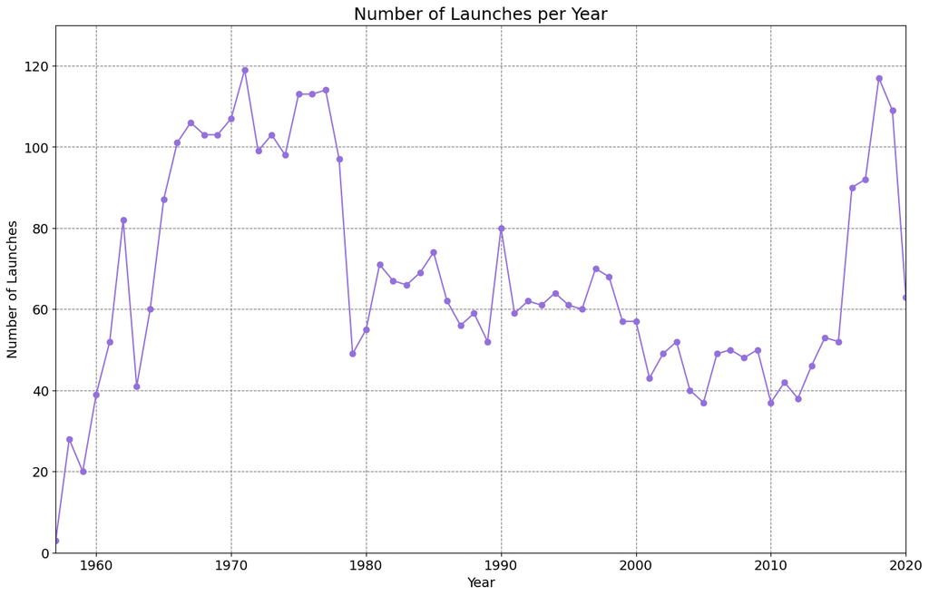

```python
plt.figure(figsize=(16,10))
plt.xticks(fontsize=14)
plt.yticks(fontsize=14)
plt.xlabel('Year', fontsize=14)
plt.ylabel('Number of Launches', fontsize=14)
plt.ylim(0,130)
plt.xlim(1957, 2020)
plt.title('Number of Launches per Year', fontsize=18)
plt.grid(color='grey', linestyle='--')

plt.plot(launches_per_year.Year, launches_per_year.Mission_Status, color='mediumpurple', marker='o')
```

We can observe that **the year 1971 was the most active with the number of launches reaching just under 120.** The second most active year was 2018. Our dataset starts at 1957 and it was also the year with the smallest amount of launches.

The first big growth in launch numbers happened from 1959 to 1962, then the number dropped sharply for one year and continued to increase again. **The years from 1965 and 1978 were definitely the most active.** After that we saw a fairly big decline and it took until 2016 for the numbers to reach similar levels again. We saw the numbers fall in 2020 again and that's where our dataset ends.

# Chart the Number of Launches Month-on-Month until the Present

To see which month has seen the highest number of launches in all time we are going to superimpose a rolling average on the month on month time series chart.

```python
grouped = df_data.groupby(['Year','Month']).size().reset_index(name='launch_count')
```

```python
grouped['year_month'] = grouped['Year'].astype(str) + ' ' + grouped['Month'].astype(str)

grouped = grouped.groupby('year_month').size().reset_index(name='launch_count')
```

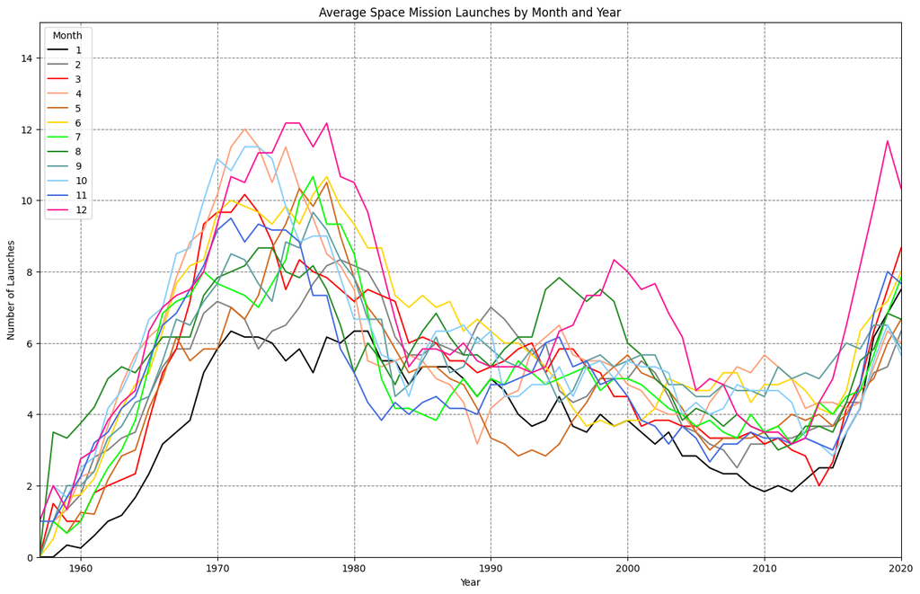

```python
launch_counts = df_data.groupby(['Year', 'Month']).size().unstack(fill_value=0)
rolling_mean = launch_counts.rolling(window=6, min_periods=1).mean()

fig, ax = plt.subplots(figsize=(16, 10))
ax.set_prop_cycle('color', ['black', 'grey', 'red', 'lightsalmon', 'chocolate', 'gold', 'lime', 'forestgreen', 'cadetblue', 'lightskyblue', 'royalblue', 'deeppink'])

for month in rolling_mean.columns:
    ax.plot(rolling_mean.index, rolling_mean[month], label=month)


ax.set_xlabel('Year')
ax.set_ylabel('Number of Launches')
ax.set_title('Average Space Mission Launches by Month and Year')
ax.legend(title='Month')
plt.ylim(0,15)
plt.xlim(1957, 2020)
plt.grid(color='grey', linestyle='--')
plt.show()
```

We can see that the most popular months tend to change every few years. However, **December was the most active month** for the biggest amount of years. With the least popular months for launches the change is not as frequent and January was at the bottom most often.

# Launches per Month: Which months are most popular and least popular for launches?

Let's look at the total amount of launches per month and see which time of year seems the best and worst for space mission.

```python
launches_per_month = df_data.groupby('Month').count()
```

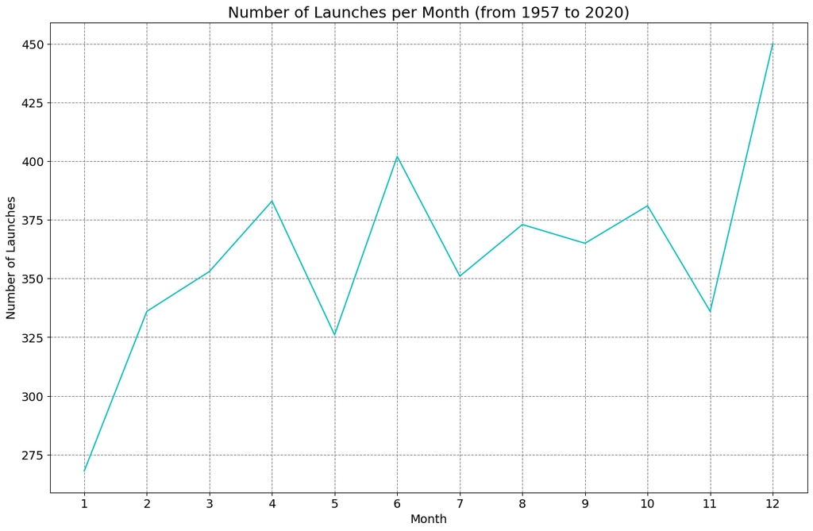

```python
plt.figure(figsize=(16,10))
plt.xticks(launches_per_month.index, fontsize=14)
plt.yticks(fontsize=14)
plt.xlabel('Month', fontsize=14)
plt.ylabel('Number of Launches', fontsize=14)
plt.title('Number of Launches per Month (from 1957 to 2020)', fontsize=18)
plt.grid(color='grey', linestyle='--')
plt.plot(launches_per_month.index, launches_per_month.Mission_Status, color='c')
```

With this graph we can see even more clearly that **December seems to be the best month for space missions with 450 launches**, whereas January is definitely the least popular with less than 275 missions.

# How has the Launch Price varied Over Time?

We are going to look at the average price of launches over time.

```python
average_price_overtime = df_data.groupby('Year', as_index=False).agg({'Price': pd.Series.mean})
```

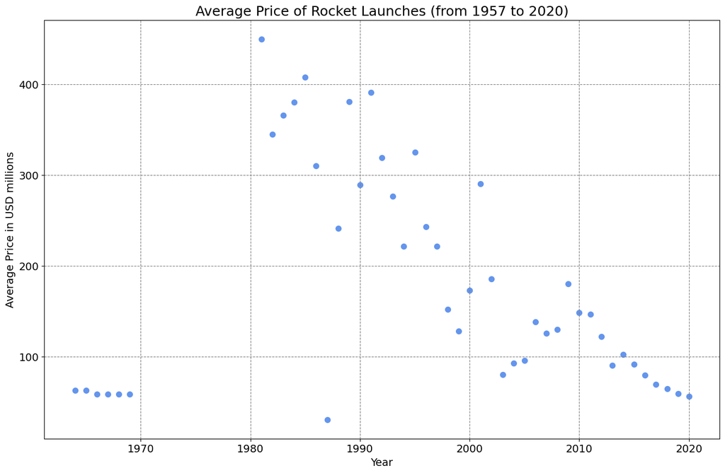

```python
plt.figure(figsize=(16,10))
plt.xticks(fontsize=14)
plt.yticks(fontsize=14)
plt.xlabel('Year', fontsize=14)
plt.ylabel('Average Price in USD millions', fontsize=14)
plt.title('Average Price of Rocket Launches (from 1957 to 2020)', fontsize=18)
plt.grid(color='grey', linestyle='--')
plt.scatter(average_price_overtime.Year, average_price_overtime.Price, color='cornflowerblue', s=50)
```

We mentioned earlier that there is some missing price data and unfortunately this affected our chart. However, with the data that we have we can see that the average price of rocket launches was steady at the beginning at around 60 mil USD. It **skyrocketed after 1980 to more than 400 mil USD** and has been on a slow declining trend until the end of our dataset in 2020.

# Chart the Number of Launches over Time by the Top 10 Organisations.

Let's check how the dominance of launches has changed over time between the different players.

```python
top_10_organisations = df_data['Organisation'].value_counts().head(10).index
df_top_10 = df_data[df_data['Organisation'].isin(top_10_organisations)]
```

```python
launch_counts = df_top_10.groupby(['Organisation', 'Year']).size().reset_index(name='Launch_Count')
```

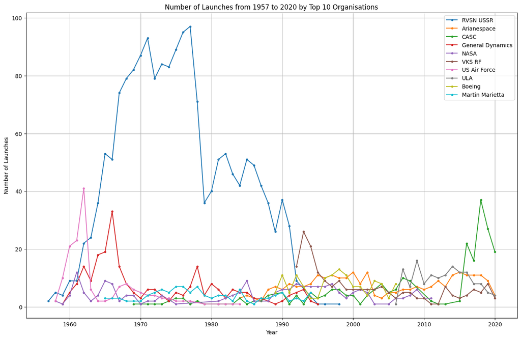

```python
plt.figure(figsize=(16, 10))

for org in top_10_organisations:
    org_data = launch_counts[launch_counts['Organisation'] == org]
    plt.plot(org_data['Year'], org_data['Launch_Count'], label=org, marker='.')

plt.xlabel('Year')
plt.ylabel('Number of Launches')
plt.title('Number of Launches from 1957 to 2020 by Top 10 Organisations')
plt.legend()
plt.grid(True)
plt.show()
```

We can observe that **from 1959 to 1962 US Air force was in the lead, but in 1963 it was massively overtaken by RVSN USSR that stayed in the lead until 1991.** Since then the leading organisation has been changing every few years and the difference between the number of launches among the organisation has decreased significantly. **In the most recent years (2016 - 2020) CASC has been in the lead.**

# Cold War Space Race: USA vs USSR

We're going to compare the numbers of space missions between USA and USSR during the cold war. The cold war lasted from 1947 until 1991. Our dataset starts in 1957 so we won't have the complete data, however we will be able to analyse the majority of the cold war launches.

We must manipulate our dataset a little bit in order to obtain this information. We'll have to change some of the countries to USSR to correspond with the former Soviet states.

There are 15 post-Soviet states in total: Armenia, Azerbaijan, Belarus, Estonia, Georgia, Kazakhstan, Kyrgyzstan, Latvia, Lithuania, Moldova, Russia, Tajikistan, Turkmenistan, Ukraine, and Uzbekistan.

We will also filter our dataset to make sure it only shows information up until 1991.

```python
def change_location_iso(iso):
  ussr_countries = ['RUS', 'KAZ', 'BLR', 'EST', 'UKR', 'KGZ', 'AZE', 'MDA', 'UZB', 'TKM', 'GEO', 'ARM', 'TJK']
  if iso == 'USA':
      return 'USA'
  elif iso in ussr_countries:
      return 'USSR'
  else:
      return None
```

```python
cold_war_df = df_data.copy()
```

```python
cold_war_df['Country_clean'] = cold_war_df['Country_clean'].apply(change_location_iso)
```

```python
cold_war_df = cold_war_df.loc[(cold_war_df['Year'] >= 1957) & (cold_war_df['Year'] <= 1991)]
```

```python
cold_war_launches = cold_war_df.Country_clean.value_counts()
```

```python
cold_war_launches
```

```
USSR    1770
USA      662
Name: Country_clean, dtype: int64
```

## Create a Plotly Pie Chart comparing the total number of launches of the USSR and the USA

```python
colors=['plum', 'burlywood']

fig = px.pie(cold_war_launches, values=cold_war_launches.values, names=cold_war_launches.index,
             title='Cold War Launches: Total Number of Launches of the USSR and USA')

fig.update_traces(textposition='inside', textinfo='percent+label',  marker=dict(colors=colors, line=dict(color='#000000', width=2)))
fig.show()
fig.write_html('8Cold War Launches: Total Number of Launches of the USSR and USA.html')
```

[interactive chart not shown]

**We can see that USSR had 1770 space missions in total, whereas the USA had 662.**

## Create a Chart that Shows the Total Number of Launches Year-On-Year by the Two Superpowers

Let's compare the number of launches year-on-year.

```python
superpowers_launches = cold_war_df.groupby(['Year', 'Country_clean']).size().reset_index(name='launch_count')
```

```python
pivot_superpowers = superpowers_launches.pivot(index='Year', columns='Country_clean', values='launch_count')
```

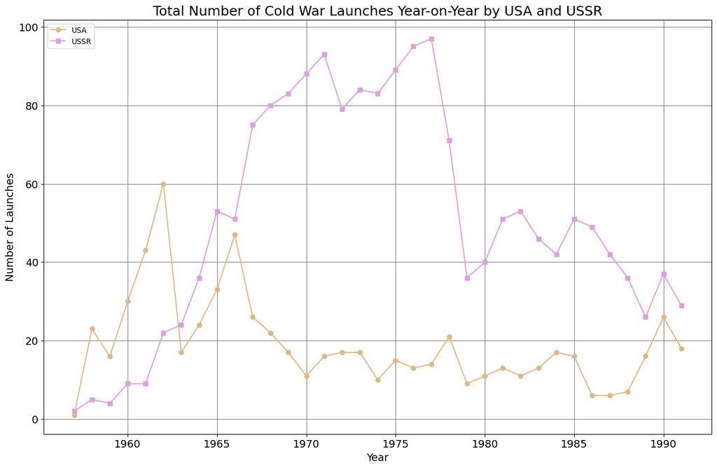

```python
plt.figure(figsize=(16,10))
plt.xticks(fontsize=14)
plt.yticks(fontsize=14)
plt.xlabel('Year', fontsize=14)
plt.ylabel('Number of Launches', fontsize=14)
plt.title('Total Number of Cold War Launches Year-on-Year by USA and USSR', fontsize=18)
plt.grid(color='grey', linestyle='-')
plt.plot(pivot_superpowers.index, pivot_superpowers.USA, color='burlywood', marker='o')
plt.plot(pivot_superpowers.index, pivot_superpowers.USSR, color='plum', marker='s')
plt.legend(['USA', 'USSR'], loc='upper left')
plt.show()
```

## Chart the Total Number of Mission Failures Year on Year.

We're going to look at the total number of mission failures year on year. The 'Mission_Status' column also contains data on partial failures and prelaunch failures, which we are ignoring for this chart.

```python
failure_by_year = df_data[df_data['Mission_Status'] == 'Failure']
```

```python
failure_by_year = failure_by_year.groupby('Year').agg({'Mission_Status': pd.Series.count})
```

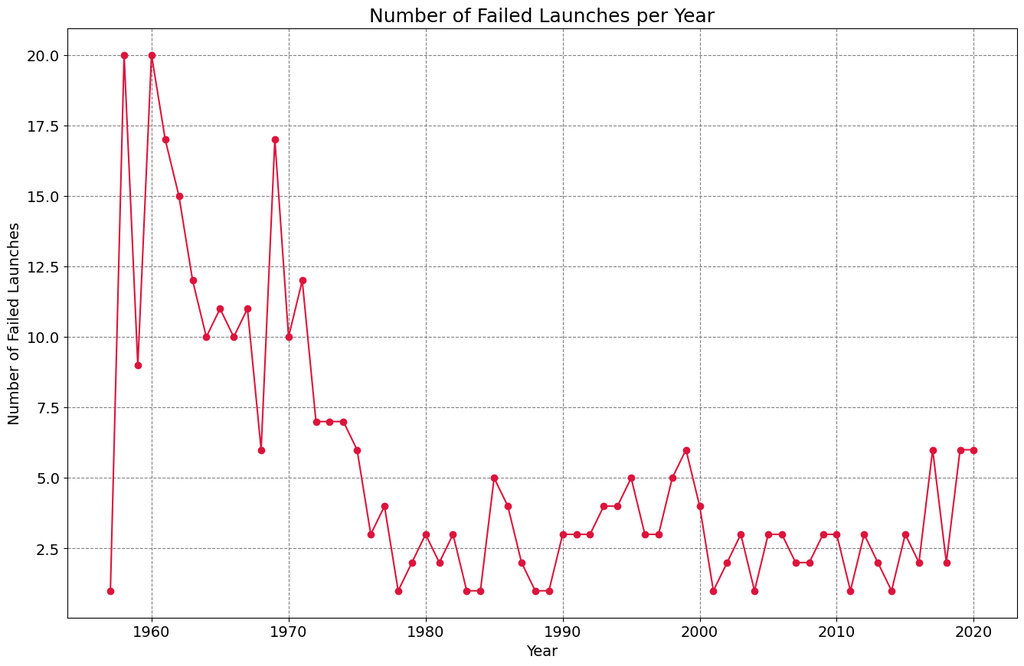

```python
plt.figure(figsize=(16,10))
plt.xticks(fontsize=14)
plt.yticks(fontsize=14)
plt.xlabel('Year', fontsize=14)
plt.ylabel('Number of Failed Launches', fontsize=14)
plt.title('Number of Failed Launches per Year', fontsize=18)
plt.grid(color='grey', linestyle='--')

plt.plot(failure_by_year.index, failure_by_year.Mission_Status, color='crimson', marker='o')
```

We can see that **most failures happened between 1958 and 1971**, twice in those years we saw the numbers reach 20. From 1971 till 1976 we saw a good decline and the number failures fell under 5 a year. Since then the number of failures mostly stayed at or under 5 a year with the exeception of 1999, 2017, 2019 and 2020. We've never had a year with 0 failures.

## Mission Status Comparison over Time

Now we are going to compare the four different types of mission status we have in our dataset: Success, Failure, Partial Failure and Prelaunch Failure.

```python
failure_vs_success = df_data.groupby(['Year', 'Mission_Status']).size().reset_index(name='Amount')
```

```python
pivot_failure_vs_success = failure_vs_success.pivot(index='Year', columns='Mission_Status', values='Amount')
```

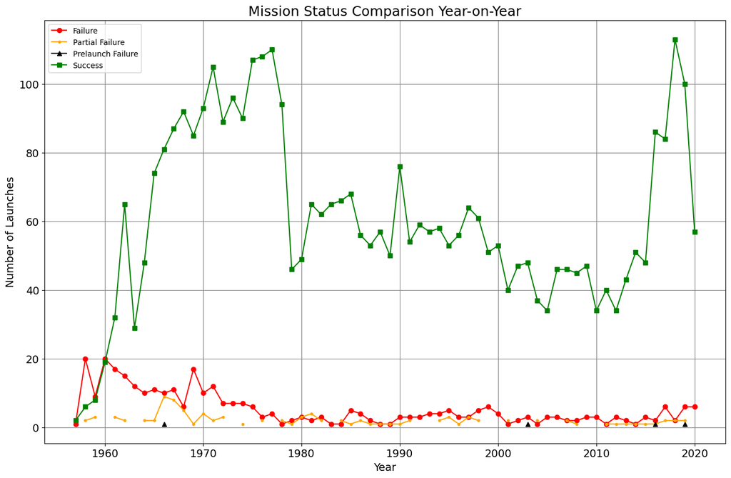

```python
plt.figure(figsize=(16,10))
plt.xticks(fontsize=14)
plt.yticks(fontsize=14)
plt.xlabel('Year', fontsize=14)
plt.ylabel('Number of Launches', fontsize=14)
plt.title('Mission Status Comparison Year-on-Year', fontsize=18)
plt.grid(color='grey', linestyle='-')
plt.plot(pivot_failure_vs_success.index, pivot_failure_vs_success['Failure'], color='red', marker='o')
plt.plot(pivot_failure_vs_success.index, pivot_failure_vs_success['Partial Failure'], color='orange', marker='.')
plt.plot(pivot_failure_vs_success.index, pivot_failure_vs_success['Prelaunch Failure'], color='black', marker='^')
plt.plot(pivot_failure_vs_success.index, pivot_failure_vs_success['Success'], color='green', marker='s')

plt.legend(['Failure', 'Partial Failure', 'Prelaunch Failure', 'Success'], loc='upper left')
plt.show()
```

## Chart the Percentage of Failures over Time

```python
pivot_failure_vs_success = pivot_failure_vs_success.fillna(0)
```

```python
pivot_failure_vs_success['Percentage'] = (pivot_failure_vs_success.Failure / (pivot_failure_vs_success.Failure + pivot_failure_vs_success['Partial Failure'] + pivot_failure_vs_success['Prelaunch Failure'] + pivot_failure_vs_success['Success'])) * 100
```

```python
bar = px.bar(y=pivot_failure_vs_success.index, x=pivot_failure_vs_success.Percentage,
             orientation='h',
             title='Percentage of Failures Over Time',
             color=pivot_failure_vs_success.Percentage)

bar.update_layout(yaxis_title='Year', xaxis_title='Percentage of Failures', coloraxis_showscale=False)
bar.update_traces(showlegend=False)

bar.show()
bar.write_html('9Percentage of Failures Over Time')
```

[interactive chart not shown]

The percentage of failures was very high at the beginning of the dataset in 1957 but has dropped fairly quickly to less than 20% in 1964. From 1972 the percentage of failures has been below 10% with one exception in 1999.

# For Every Year Show which Country was in the Lead in terms of Total Number of Launches up to and including including 2020

```python
number_of_launches = df_data.groupby(['Year',  'Country', 'Organisation']).size().reset_index(name='Launch_count')
```

```python
lead_launches = number_of_launches.loc[number_of_launches.groupby('Year')['Launch_count'].idxmax()]
```

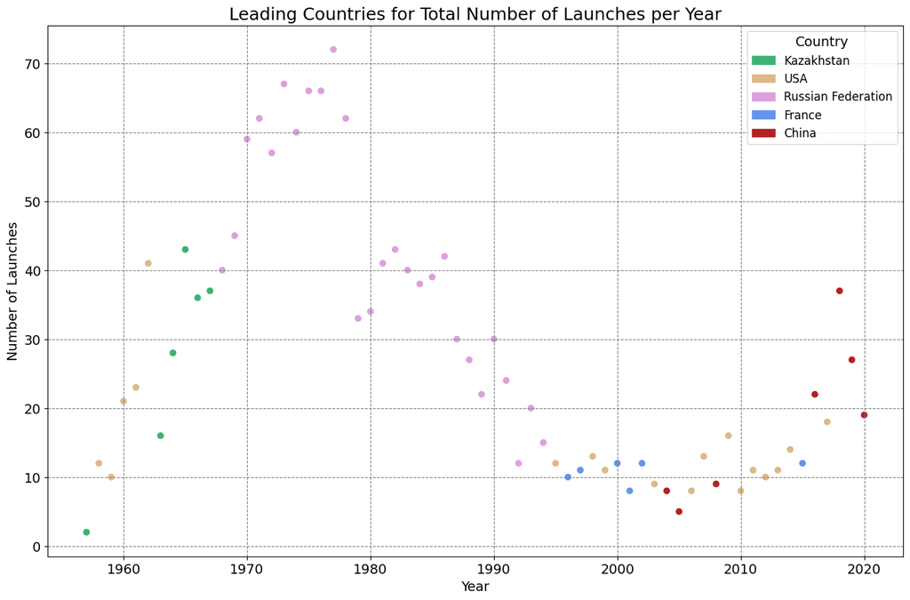

```python
colors = {'Kazakhstan':'mediumseagreen', 'USA':'burlywood', 'Russian Federation':'plum', 'France':'cornflowerblue', 'China':'firebrick'}

plt.figure(figsize=(16,10))
plt.xticks(fontsize=14)
plt.yticks(fontsize=14)
plt.xlabel('Year', fontsize=14)
plt.ylabel('Number of Launches', fontsize=14)
plt.title('Leading Countries for Total Number of Launches per Year', fontsize=18)
plt.grid(color='grey', linestyle='--')
scatter = plt.scatter(x=lead_launches['Year'], y=lead_launches['Launch_count'], c=lead_launches['Country'].map(colors))
legend_patches = [mpatches.Patch(color=color, label=country) for country, color in colors.items()]
plt.legend(handles=legend_patches, title="Country", fontsize=12, title_fontsize=14)
plt.show()
```

# Show which Country was in the Lead in terms of Total Number of **Successful** Launches up to and including 2020

```python
successful_only = df_data[df_data['Mission_Status'] == 'Success']
```

```python
successful_launches_amount = successful_only.groupby(['Year',  'Country', 'Organisation']).size().reset_index(name='Launch_count')
```

```python
successful_leads = successful_launches_amount.loc[successful_launches_amount.groupby('Year')['Launch_count'].idxmax()]
```

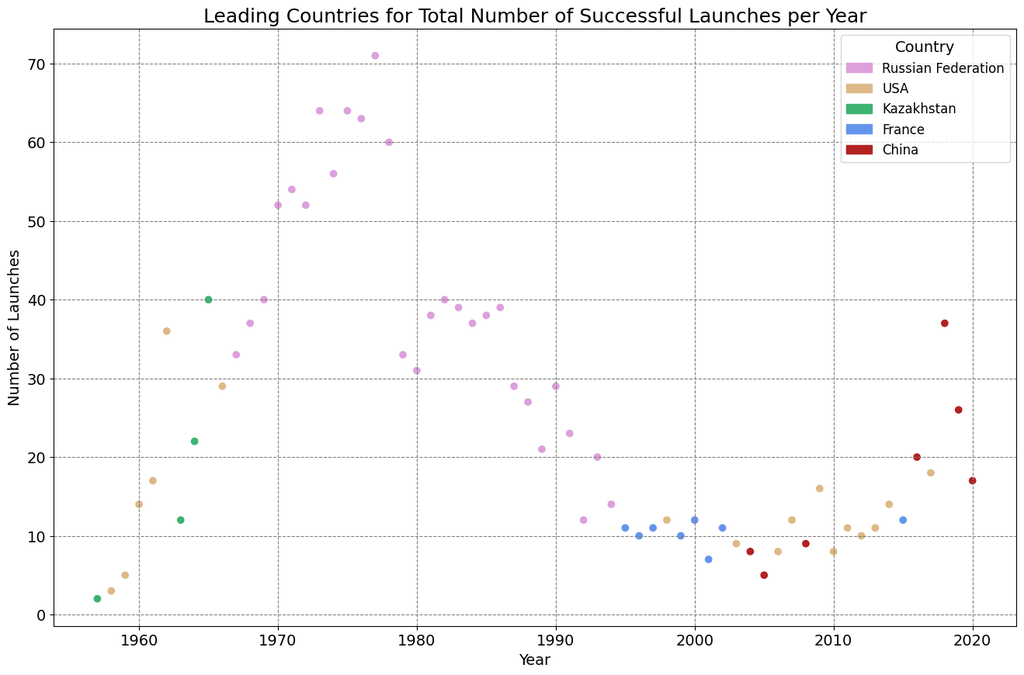

```python
colors = {'Russian Federation':'plum', 'USA':'burlywood', 'Kazakhstan':'mediumseagreen', 'France':'cornflowerblue', 'China':'firebrick'}
plt.figure(figsize=(16,10))
plt.xticks(fontsize=14)
plt.yticks(fontsize=14)
plt.xlabel('Year', fontsize=14)
plt.ylabel('Number of Launches', fontsize=14)
plt.title('Leading Countries for Total Number of Successful Launches per Year', fontsize=18)
plt.grid(color='grey', linestyle='--')
scatter = plt.scatter(x=successful_leads['Year'], y=successful_leads['Launch_count'], c=successful_leads['Country'].map(colors))
legend_patches = [mpatches.Patch(color=color, label=country) for country, color in colors.items()]
plt.legend(handles=legend_patches, title="Country", fontsize=12, title_fontsize=14)
plt.show()
```

The chart for successful launches looks quite similar but there are some differences. Kazakhstan was in the lead for 4 years rather than 6. France was in the lead for 8 years rather than 6.

# Create a Year-on-Year Chart Showing the Organisation Doing the Most Number of Launches

Which organisation was dominant in the 1970s and 1980s? Which organisation was dominant in 2018, 2019 and 2020?

```python
print(lead_launches.Organisation.unique())
```

```
['RVSN USSR' 'US Navy' 'US Air Force' 'VKS RF' 'Lockheed' 'Arianespace'
 'Boeing' 'CASC' 'ULA' 'SpaceX']
```

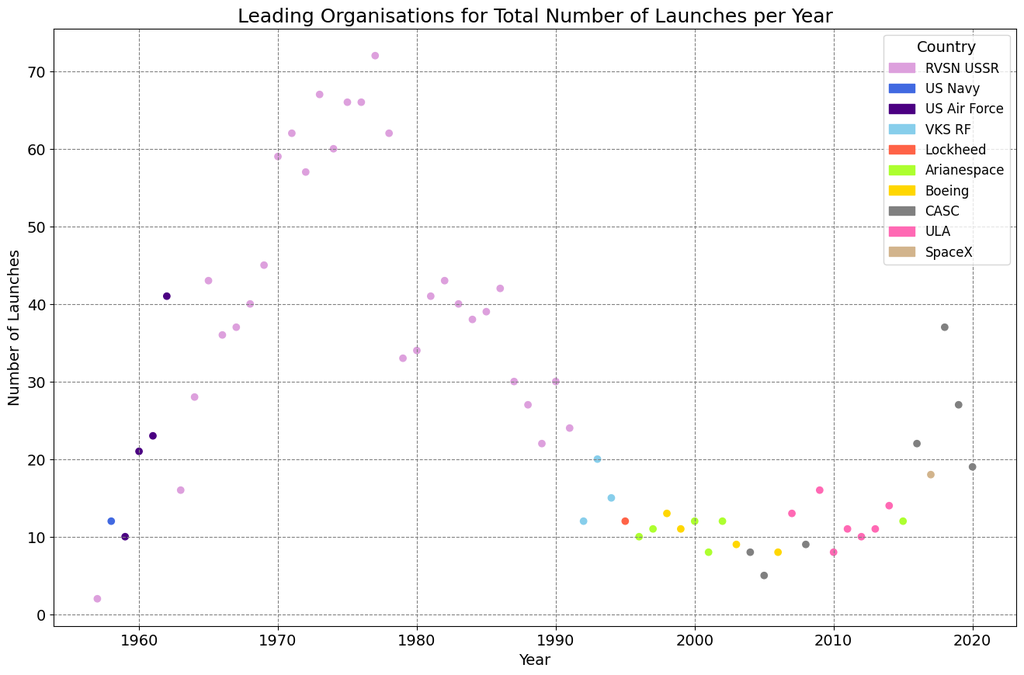

```python
colors= {'RVSN USSR':'plum', 'US Navy':'royalblue', 'US Air Force':'indigo', 'VKS RF':'skyblue', 'Lockheed':'tomato', 'Arianespace':'greenyellow',
 'Boeing':'gold', 'CASC':'grey', 'ULA':'hotpink', 'SpaceX':'tan'}
plt.figure(figsize=(16,10))
plt.xticks(fontsize=14)
plt.yticks(fontsize=14)
plt.xlabel('Year', fontsize=14)
plt.ylabel('Number of Launches', fontsize=14)
plt.title('Leading Organisations for Total Number of Launches per Year', fontsize=18)
plt.grid(color='grey', linestyle='--')
scatter = plt.scatter(x=lead_launches['Year'], y=lead_launches['Launch_count'], c=lead_launches['Organisation'].map(colors))
legend_patches = [mpatches.Patch(color=color, label=country) for country, color in colors.items()]
plt.legend(handles=legend_patches, title="Country", fontsize=12, title_fontsize=14)
plt.show()
```

Just like in our previous observations, we can see here that **RVSN USSR was the leading organisation for the longest time (30 years in total)**. From 1957 to 1991 there were only 3 organisations in the lead (RVSN USSR, US Navy and US Air Force). From 1992 we can notice a bigger variety of organisations and smaller total number of launches.